# Project Business Statistics: E-news Express

**Marks: 60**

## Define Problem Statement and Objectives

#### E-news Express, an online news portal, aims to expand its business by acquiring new subscribers.

# Problem :

Executives think that the company has a decline in new monthly subscribers compared to the past year as the current webpage is not designed well interms of outline and recommended content to make a decision to subscribe.

Objective :

The design team came up with a new landing page with new outline and more relevant content for the user. An experiment has been conducted by the data science team selecting 100 users as a random sample to test the effectiveness of the new landing page.  
As a data scientist we have to peform data analysis and statistical analysis (@ level of significance = 5%) to determine the effectiveness of the new landing page in gathering new subscribers for the news portal by answering the following questions:

1. Do the users spend more time on the new landing page than on the existing landing page?
2. Is the conversion rate (the proportion of users who visit the landing page and get converted) for the new page greater than the conversion rate for the old page?
3. Does the converted status depend on the preferred language?
4. Is the time spent on the new page the same for the different language users?

## Import all the necessary libraries

```python
import numpy as np
import pandas as pd
import seaborn as sns
import matplotlib.pyplot as plt

%matplotlib inline
import scipy.stats as stats
```

## Reading the Data into a DataFrame

```python
#lets read the data using read_csv function from pandas
df = pd.read_csv('C:/Users/SridharGudimella/Desktop/DS training Notebooks/datasets/abtest.csv')
#taking a copy of the dataset to data
data_enews = df.copy()
```

## Explore the dataset and extract insights using Exploratory Data Analysis

- Data Overview
  - Viewing the first and last few rows of the dataset
  - Checking the shape of the dataset
  - Getting the statistical summary for the variables
- Check for missing values
- Check for duplicates

```python
#lets view the first 5 rows of the dataset
data_enews.head()
```

|  | user_id | group | landing_page | time_spent_on_the_page | converted | language_preferred |
| --- | --- | --- | --- | --- | --- | --- |
| 0 | 546592 | control | old | 3.48 | no | Spanish |
| 1 | 546468 | treatment | new | 7.13 | yes | English |
| 2 | 546462 | treatment | new | 4.40 | no | Spanish |
| 3 | 546567 | control | old | 3.02 | no | French |
| 4 | 546459 | treatment | new | 4.75 | yes | Spanish |

```python
#lets view the first 5 rows of the dataset
data_enews.tail()
```

|  | user_id | group | landing_page | time_spent_on_the_page | converted | language_preferred |
| --- | --- | --- | --- | --- | --- | --- |
| 95 | 546446 | treatment | new | 5.15 | no | Spanish |
| 96 | 546544 | control | old | 6.52 | yes | English |
| 97 | 546472 | treatment | new | 7.07 | yes | Spanish |
| 98 | 546481 | treatment | new | 6.20 | yes | Spanish |
| 99 | 546483 | treatment | new | 5.86 | yes | English |

```python
#checking the shape of the dataset to see how many rows and columns as there.
data_enews.shape
```

```
(100, 6)
```

Random sample has 100 rows with 6 columns.

```python
data_enews.info()
```

```
<class 'pandas.core.frame.DataFrame'>
RangeIndex: 100 entries, 0 to 99
Data columns (total 6 columns):
 #   Column                  Non-Null Count  Dtype
---  ------                  --------------  -----
 0   user_id                 100 non-null    int64
 1   group                   100 non-null    object
 2   landing_page            100 non-null    object
 3   time_spent_on_the_page  100 non-null    float64
 4   converted               100 non-null    object
 5   language_preferred      100 non-null    object
dtypes: float64(1), int64(1), object(4)
memory usage: 4.8+ KB
```

```python
#lets see the statistical summary of the dataset
data_enews.describe(include = 'all').T
```

|  | count | unique | top | freq | mean | std | min | 25% | 50% | 75% | max |
| --- | --- | --- | --- | --- | --- | --- | --- | --- | --- | --- | --- |
| user_id | 100.0 | NaN | NaN | NaN | 546517.0 | 52.295779 | 546443.0 | 546467.75 | 546492.5 | 546567.25 | 546592.0 |
| group | 100 | 2 | control | 50 | NaN | NaN | NaN | NaN | NaN | NaN | NaN |
| landing_page | 100 | 2 | old | 50 | NaN | NaN | NaN | NaN | NaN | NaN | NaN |
| time_spent_on_the_page | 100.0 | NaN | NaN | NaN | 5.3778 | 2.378166 | 0.19 | 3.88 | 5.415 | 7.0225 | 10.71 |
| converted | 100 | 2 | yes | 54 | NaN | NaN | NaN | NaN | NaN | NaN | NaN |
| language_preferred | 100 | 3 | Spanish | 34 | NaN | NaN | NaN | NaN | NaN | NaN | NaN |

# Insights:

1. Average time spent on the page is 5.37780 minutes
2. Standard deviation of the time spent on the page is 2.378166 minutes
3. Minimum time spent on the page is 0.19 minutes
4. Max time spent on the page is 10.71 min
5. 50 percentile of the time spent on the page is 5.415 min
6. Top preferred language is Spanish
7. Random sample doesnt have any missing values as the count for all the columns is 100.

```python
#lets check the null values
data_enews.isnull().values.any()
```

```
False
```

```python
data_enews.isnull().sum()
```

```
user_id                   0
group                     0
landing_page              0
time_spent_on_the_page    0
converted                 0
language_preferred        0
dtype: int64
```

# Insights:

No null values in the dataset.

```python
# lets see if we have duplicates in the dataset
data_enews.duplicated()
```

```
0     False
1     False
2     False
3     False
4     False
      ...
95    False
96    False
97    False
98    False
99    False
Length: 100, dtype: bool
```

# Insights :

There are no duplicates in the random sample.

```python
#if we have any duplicates they would be removed, but in our case we dont have any.
data_enews.drop_duplicates()
```

|  | user_id | group | landing_page | time_spent_on_the_page | converted | language_preferred |
| --- | --- | --- | --- | --- | --- | --- |
| 0 | 546592 | control | old | 3.48 | no | Spanish |
| 1 | 546468 | treatment | new | 7.13 | yes | English |
| 2 | 546462 | treatment | new | 4.40 | no | Spanish |
| 3 | 546567 | control | old | 3.02 | no | French |
| 4 | 546459 | treatment | new | 4.75 | yes | Spanish |
| ... | ... | ... | ... | ... | ... | ... |
| 95 | 546446 | treatment | new | 5.15 | no | Spanish |
| 96 | 546544 | control | old | 6.52 | yes | English |
| 97 | 546472 | treatment | new | 7.07 | yes | Spanish |
| 98 | 546481 | treatment | new | 6.20 | yes | Spanish |
| 99 | 546483 | treatment | new | 5.86 | yes | English |

100 rows × 6 columns

### Univariate Analysis

```python
#lets analyze the random sample set
data_enews.nunique()
```

```
user_id                   100
group                       2
landing_page                2
time_spent_on_the_page     94
converted                   2
language_preferred          3
dtype: int64
```

#### Insights

Random sample contains unique user data

# Time Spent on the page

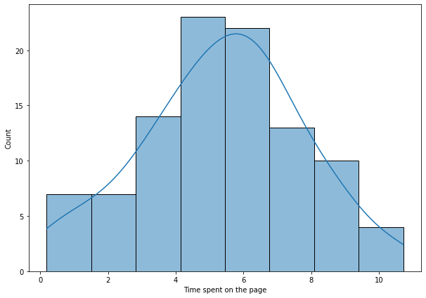

```python
# lets plot a histplot to understand time spent on the page
plt.figure(figsize=(10,7))
sns.histplot(data =data_enews, x = 'time_spent_on_the_page', kde = True);
plt.xlabel('Time spent on the page')
plt.show()
```

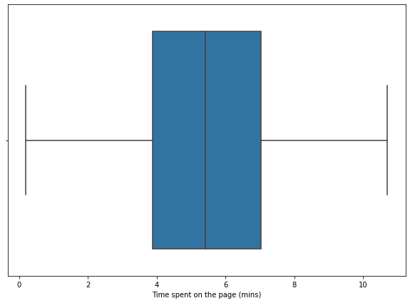

```python
# lets plot a boxplot to understand outliers if any
plt.figure(figsize=(10,7))
sns.boxplot(data =data_enews, x = 'time_spent_on_the_page');
plt.xlabel('Time spent on the page (mins)')
plt.show()
```

# Group

```python
data_enews['group'].value_counts()
```

```
control      50
treatment    50
Name: group, dtype: int64
```

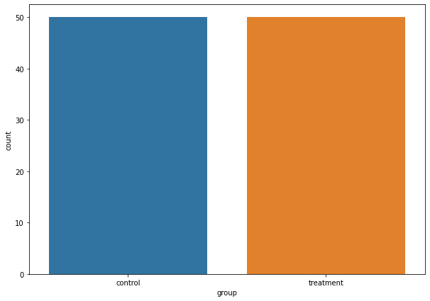

```python
#lets see a countplot on the categorical data column "group"
plt.figure(figsize=(10,7))
sns.countplot(data = data_enews,x = 'group');
plt.show()
```

# Landing page

```python
# lets get the understanding on landing page column
data_enews['landing_page'].nunique()
```

```
2
```

```python
data_enews['landing_page'].unique()
```

```
array(['old', 'new'], dtype=object)
```

# Insights:

Landing page column has only old and new values, no NaN or missing info.

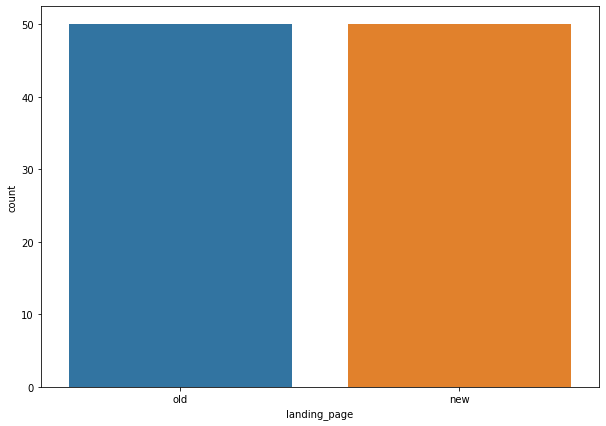

```python
# lets plot the count plot for landing page column
plt.figure(figsize=(10,7))
sns.countplot(data =data_enews, x = 'landing_page');
plt.show()
```

```python
data_enews['landing_page'].value_counts()
```

```
old    50
new    50
Name: landing_page, dtype: int64
```

# Converted

```python
data_enews['converted'].nunique()
```

```
2
```

```python
data_enews['converted'].unique()
```

```
array(['no', 'yes'], dtype=object)
```

```python
data_enews['converted'].value_counts()
```

```
yes    54
no     46
Name: converted, dtype: int64
```

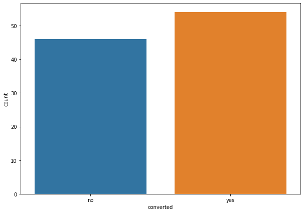

```python
# lets plot the count plot for converted column
plt.figure(figsize=(10,7))
sns.countplot(data =data_enews, x = 'converted');
plt.show()
```

## Language Preferred

```python
#lets analyse the language preferred using value_counts()
data_enews['language_preferred'].value_counts()
```

```
Spanish    34
French     34
English    32
Name: language_preferred, dtype: int64
```

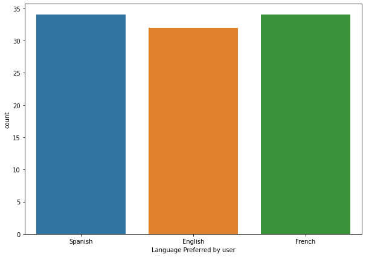

```python
plt.figure(figsize=(10,7))
sns.countplot(data = data_enews, x = 'language_preferred');
plt.xlabel('Language Preferred by user')
plt.show()
```

# Insights:

# landing page vs time spent on the page

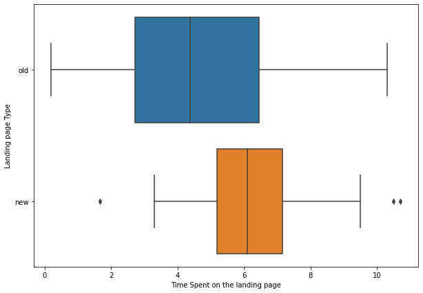

```python
# lets understand  time spent on landing page vs time spent on the page
plt.figure(figsize=(10,7))
sns.boxplot(data= data_enews,  x = 'time_spent_on_the_page',y = 'landing_page');
plt.xlabel('Time Spent on the landing page')
plt.ylabel('Landing page Type')
plt.show()
```

# Insights :

Plot shows 50 % of the time spent on the new landing page is more than the 50 % of the time spent on the old landing page.

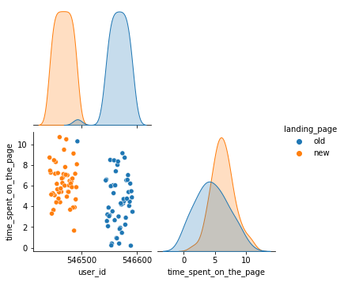

```python
#lets do a pairplot to understand all the numerical columns with hue on landing page
plt.figure(figsize=(10,7))
sns.pairplot(data = data_enews,corner=True,hue = 'landing_page');
plt.show()
```

# Insights :

Pair plot shows that the time spent on the page and landing page have relation.

# Time spent on the page vs Language preferred

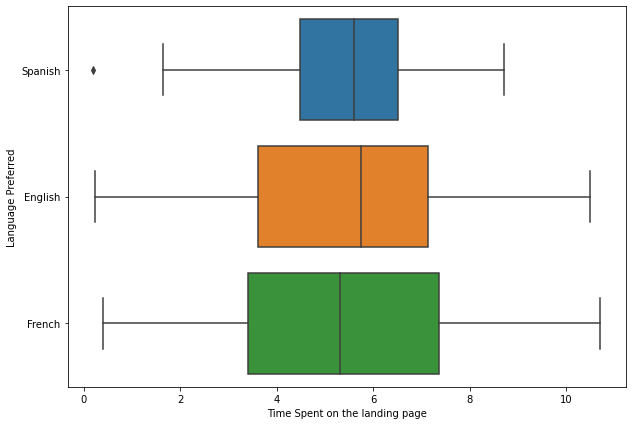

```python
# lets try to answer this question visually
# Is the time spent on the new page base on language ?
plt.figure(figsize=(10,7))
sns.boxplot(data= data_enews, x = 'time_spent_on_the_page',y = 'language_preferred');
plt.xlabel('Time Spent on the landing page')
plt.ylabel('Language Preferred')
plt.show()
```

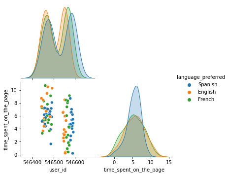

```python
#lets do a pair plot to understand the time spent vs language preferred
plt.figure(figsize=(10,7))
sns.pairplot(data = data_enews,corner=True,hue = 'language_preferred');
plt.show()
```

# Insights :

# converted vs language preferred

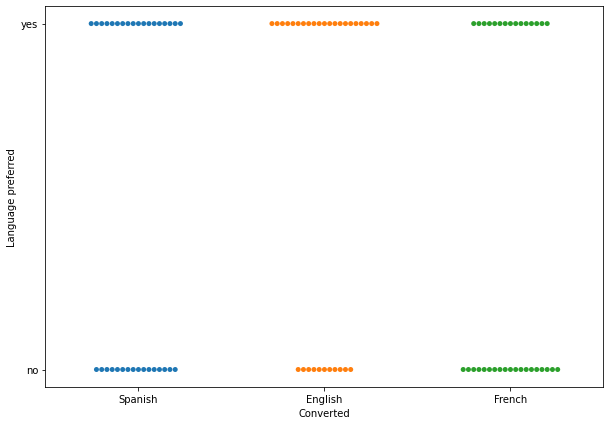

```python
# lets try to answer this question visually
# Is the converted status dependent on language preffered
plt.figure(figsize=(10,7))
sns.swarmplot(data= data_enews, y = 'converted', x = 'language_preferred');
plt.ylabel('Language preferred')
plt.xlabel('Converted')
plt.show()
```

# Time spent on the page vs converted

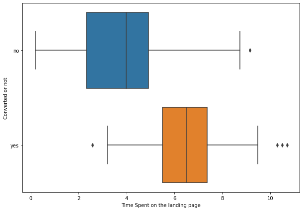

```python
#lets plot box plot for time spent on the page and converted column
plt.figure(figsize=(10, 7))
sns.boxplot(data = data_enews, x = 'time_spent_on_the_page', y = 'converted')
plt.xlabel('Time Spent on the landing page')
plt.ylabel('Converted or not')
plt.show()
```

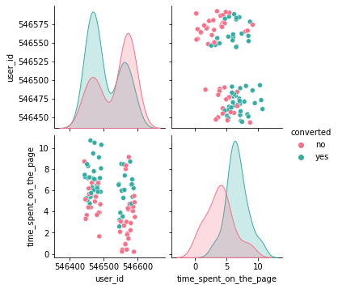

```python
plt.figure(figsize=(10, 7))
sns.pairplot(data = data_enews, hue = 'converted',palette='husl');
plt.xlabel('Time Spent on the landing page')
plt.ylabel('Converted or not')
plt.show()
```

# Insights :

Average Time spent on the landing page is more when users are converted to subscribers. Pairplot shows that users who got converted to subscribers spend more time than the non subscribers.

## 1. Do the users spend more time on the new landing page than the existing landing page?

### Perform Visual Analysis

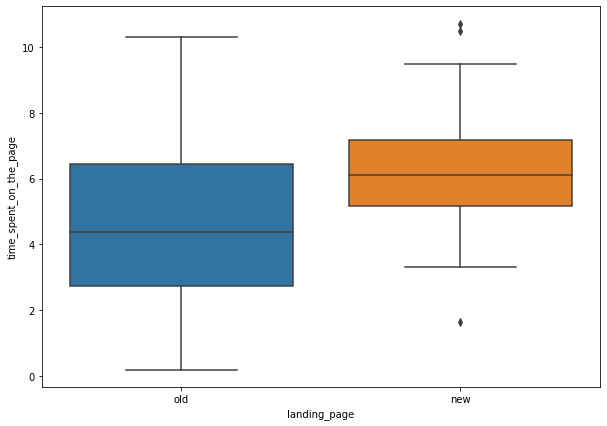

```python
#lets try to understand if time spent is more on the new landing page than the existing landing page
#lets do a box plot to understand this
plt.figure(figsize=(10,7))
sns.boxplot(x = 'landing_page', y = 'time_spent_on_the_page', data = data_enews)
plt.show()
```

### Step 1: Define the null and alternate hypotheses

###### Ho : Time spent on the new landing page is same as time spent on the old landing page

Ha : Time spent on the new landing page is more than the time spent on the old landing page

### Step 2: Select Appropriate test

This is one tailed test with two independent populations We are talking about average time spent on the new landing page vs existing landing page, so they are independent. Standard deviations are unknown. Based on this we can do two sample independent test.

Let's check the standard deviations to see if they are equal or different.

### Step 3: Decide the significance level

Level of significance is 0.05

### Step 4: Collect and prepare data

##### Before getting the data lets do a subset of the data with timespent on new landing page and other with existing landing page.

```python
total_time_spent_new_landing      = data_enews[data_enews['landing_page'] == 'new']['time_spent_on_the_page']
total_time_spent_existing_landing = data_enews[data_enews['landing_page'] == 'old']['time_spent_on_the_page']
```

# lets find the standard deviations to select the accurate test

```python
# find the sample means and sample standard deviations for the two samples
print('The mean time spent on the landing page new is ' + str(total_time_spent_new_landing.mean()))
print('The mean time spent on the landing page existing is ' + str(total_time_spent_existing_landing.mean()))
print('The standard deviation of time spent on the landing page new is ' + str(round(total_time_spent_new_landing.std(),2)))
print('The standard deviation of time spent on the landing page existing  is ' + str(round(total_time_spent_existing_landing.std(),2)))
```

```
The mean time spent on the landing page new is 6.2232
The mean time spent on the landing page existing is 4.532400000000001
The standard deviation of time spent on the landing page new is 1.82
The standard deviation of time spent on the landing page existing  is 2.58
```

# Let's test whether the T-test assumptions are satisfied or not

Continuous data - Yes, the time spent on the landing page a continuous scale.

Normally distributed populations - Yes, we can see from the visualizatins that the populations are assumed to be normal. Independent populations - As we are taking random samples for two different groups, the two samples are from two independent populations. Unequal population standard deviations - As the sample standard deviations are different, the population standard deviations may be assumed to be different. Random sampling from the population - Yes, we are informed that the collected sample is a simple random sample.

We can use two sample T-test for this problem.

### Step 5: Calculate the p-value

```python
#import the required functions
from scipy.stats import ttest_ind

# find the p-value
test_stat, p_value = ttest_ind(total_time_spent_new_landing, total_time_spent_existing_landing, equal_var = False, alternative = 'greater')
print('The p-value is ', p_value)
```

```
The p-value is  0.0001392381225166549
```

### Step 6: Compare the p-value with $\alpha$

```python
# print the conclusion based on p-value
if p_value < 0.05:
    print(f'As the p-value {p_value} is less than the level of significance, we reject the null hypothesis.')
else:
    print(f'As the p-value {p_value} is greater than the level of significance, we fail to reject the null hypothesis.')
```

```
As the p-value 0.0001392381225166549 is less than the level of significance, we reject the null hypothesis.
```

### Step 7: Draw inference

We can reject the null hypothesis as p value is less than level of significance. We can conclude that the time spent on the new landing page is more than the existing landing page.

**A similar approach can be followed to answer the other questions.**

## 2. Is the conversion rate (the proportion of users who visit the landing page and get converted) for the new page greater than the conversion rate for the old page?

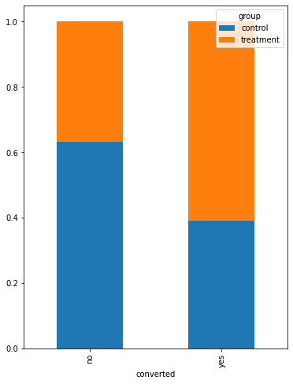

```python
# complete the code to visually compare the conversion rate for the new page and the conversion rate for the old page
pd.crosstab(data_enews['converted'],data_enews['group'],normalize='index').plot(kind="bar", figsize=(6,8),stacked=True)
plt.show()
```

### Null Hypothesis :

```
Convertion rate for the new page is same as convertion rate for the existing page.
```

#### Alternate Hypothesis :

```
Convertion rate for the new page is more than the convertion rate for the existing page.
```

#### Select appropriate test :

```
This is one tailed test with two independent populations and we are talking about proportions so we can select the two sample independent z test.
```

###### Level of Significance :

[output not shown]

#### Collect data

```python
# calculate the number of converted users in the treatment group
new_converted = data_enews[data_enews['group'] == 'treatment']['converted'].value_counts()['yes']
# calculate the number of converted users in the control group
old_converted = data_enews[data_enews['group'] =='control']['converted'].value_counts()['yes']

n_control = data_enews.group.value_counts()['control'] # total number of users in the control group
n_treatment = data_enews.group.value_counts()['treatment'] # total number of users in the treatment group

print('The numbers of users served the new and old pages are {0} and {1} respectively'.format(n_control, n_treatment ))
```

```
The numbers of users served the new and old pages are 50 and 50 respectively
```

#### Calculate p-value

```python
# import the required fuction
from statsmodels.stats.proportion import proportions_ztest

# find the p-value
test_stat, p_value = proportions_ztest([new_converted,old_converted], [n_control,n_treatment],alternative='larger')
print('The p-value is ' + str(p_value))
```

```
The p-value is 0.008026308204056278
```

#### Conclusion based on p-value

```python
# print the conclusion based on p-value
if p_value < 0.05:
    print(f'As the p-value {p_value} is less than the level of significance, we reject the null hypothesis.')
else:
    print(f'As the p-value {p_value} is greater than the level of significance, we fail to reject the null hypothesis.')
```

```
As the p-value 0.008026308204056278 is less than the level of significance, we reject the null hypothesis.
```

We reject the null hypothesis as pvalue is less than the level of significance.

We conclude the Convertion rate for the new page is more than the convertion rate for the existing page.

## 3. Is the conversion and preferred language are independent or related?

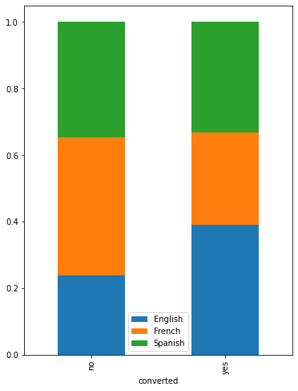

```python
#lets try to do a visual relation for the converted and preffered language columns
# as they both are categorical lets do a contingnecy table
pd.crosstab(data_enews['converted'],data_enews['language_preferred'],normalize='index').plot(kind="bar", figsize=(6,8),stacked=True)
plt.legend()
plt.show()
```

#### Null Hypothesis :

Converted status is independent of preferred language.

#### Alternative Hypothesis :

Converted status is dependent of preferred language.

#### Select appropriate test

This is a test for two categorical variables converted status and preferred language that are independent. We can use chi-square test of independence.

#### Define Level of Significance

###### Let's test whether the assumptions are satisfied or not

```
Categorical variables - Yes
Expected value of the number of sample observations in each level of the variable is at least 5 - Yes, the number of observations in each level is greater than 5.
Random sampling from the population - Yes,collected sample is a simple random sample.
```

#### Collect and prepare the data

```python
# lets build a contingency table
contingency_table = pd.crosstab(data_enews['converted'],data_enews['language_preferred'])
contingency_table
```

| language_preferred converted | English | French | Spanish |
| --- | --- | --- | --- |
| no | 11 | 19 | 16 |
| yes | 21 | 15 | 18 |

#### Calculate the p-value

```python
# import the required function
from scipy.stats import chi2_contingency

# find the p-value
chi, p_value, dof, expected = chi2_contingency(contingency_table)
print('The p-value is', p_value)
```

```
The p-value is 0.21298887487543447
```

#### Conclusion based on pvalue

```python
# print the conclusion based on p-value
if p_value < 0.05:
    print(f'As the p-value {p_value} is less than the level of significance, we reject the null hypothesis.')
else:
    print(f'As the p-value {p_value} is greater than the level of significance, we fail to reject the null hypothesis.')
```

```
As the p-value 0.21298887487543447 is greater than the level of significance, we fail to reject the null hypothesis.
```

#### Pvalue is greater than the level of significance, we fail to reject the null hypothesis.

Converted status is independent of language preferred. or We do not have enough statistical significance to conclude that converted status is dependent of language preferred at 5% significance level.

## 4. Is the time spent on the new page same for the different language users?

### Perform visual analysis

```python
#lets find the subset of data for timespent on the new page
timespentonnewpage = data_enews[data_enews['landing_page'] == 'new']
timespentonnewpage.reset_index(inplace=True)
timespentonnewpage
```

|  | index | user_id | group | landing_page | time_spent_on_the_page | converted | language_preferred |
| --- | --- | --- | --- | --- | --- | --- | --- |
| 0 | 1 | 546468 | treatment | new | 7.13 | yes | English |
| 1 | 2 | 546462 | treatment | new | 4.40 | no | Spanish |
| 2 | 4 | 546459 | treatment | new | 4.75 | yes | Spanish |
| 3 | 6 | 546448 | treatment | new | 5.25 | yes | French |
| 4 | 8 | 546461 | treatment | new | 10.71 | yes | French |
| 5 | 12 | 546491 | treatment | new | 5.86 | yes | Spanish |
| 6 | 13 | 546478 | treatment | new | 6.03 | yes | French |
| 7 | 15 | 546466 | treatment | new | 6.27 | yes | Spanish |
| 8 | 16 | 546443 | treatment | new | 8.73 | no | English |
| 9 | 22 | 546450 | treatment | new | 3.65 | no | English |
| 10 | 23 | 546475 | treatment | new | 7.02 | yes | English |
| 11 | 24 | 546456 | treatment | new | 6.18 | no | Spanish |
| 12 | 25 | 546455 | treatment | new | 4.39 | no | English |
| 13 | 26 | 546469 | treatment | new | 9.49 | yes | English |
| 14 | 28 | 546471 | treatment | new | 7.81 | yes | French |
| 15 | 30 | 546464 | treatment | new | 5.41 | yes | English |
| 16 | 38 | 546487 | treatment | new | 1.65 | no | Spanish |
| 17 | 42 | 546489 | treatment | new | 7.16 | yes | Spanish |
| 18 | 43 | 546453 | treatment | new | 7.16 | yes | English |
| 19 | 44 | 546488 | treatment | new | 3.91 | no | English |
| 20 | 46 | 546460 | treatment | new | 5.37 | yes | French |
| 21 | 47 | 546458 | treatment | new | 7.23 | yes | Spanish |
| 22 | 48 | 546492 | treatment | new | 8.08 | yes | Spanish |
| 23 | 49 | 546473 | treatment | new | 10.50 | yes | English |
| 24 | 51 | 546457 | treatment | new | 5.65 | no | English |
| 25 | 52 | 546479 | treatment | new | 6.47 | yes | Spanish |
| 26 | 54 | 546482 | treatment | new | 6.41 | yes | Spanish |
| 27 | 57 | 546454 | treatment | new | 8.30 | yes | French |
| 28 | 60 | 546470 | treatment | new | 6.01 | yes | French |
| 29 | 61 | 546467 | treatment | new | 6.79 | yes | French |
| 30 | 65 | 546445 | treatment | new | 7.27 | yes | French |
| 31 | 68 | 546484 | treatment | new | 6.70 | no | Spanish |
| 32 | 71 | 546476 | treatment | new | 5.42 | yes | French |
| 33 | 72 | 546452 | treatment | new | 5.08 | yes | English |
| 34 | 73 | 546444 | treatment | new | 7.46 | yes | English |
| 35 | 77 | 546485 | treatment | new | 3.88 | no | Spanish |
| 36 | 78 | 546486 | treatment | new | 9.12 | yes | French |
| 37 | 80 | 546490 | treatment | new | 4.68 | no | French |
| 38 | 81 | 546449 | treatment | new | 5.26 | yes | French |
| 39 | 82 | 546463 | treatment | new | 5.74 | yes | Spanish |
| 40 | 86 | 546465 | treatment | new | 6.71 | no | English |
| 41 | 87 | 546480 | treatment | new | 3.68 | no | French |
| 42 | 88 | 546447 | treatment | new | 3.30 | no | French |
| 43 | 90 | 546477 | treatment | new | 5.40 | no | French |
| 44 | 91 | 546451 | treatment | new | 8.47 | yes | English |
| 45 | 93 | 546474 | treatment | new | 4.94 | no | French |
| 46 | 95 | 546446 | treatment | new | 5.15 | no | Spanish |
| 47 | 97 | 546472 | treatment | new | 7.07 | yes | Spanish |
| 48 | 98 | 546481 | treatment | new | 6.20 | yes | Spanish |
| 49 | 99 | 546483 | treatment | new | 5.86 | yes | English |

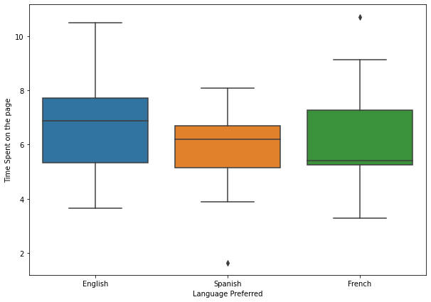

```python
#lets do a box plot for timespent and language preferred
plt.figure(figsize=(10,7))
sns.boxplot(data = timespentonnewpage, y = 'time_spent_on_the_page',x = 'language_preferred')
plt.xlabel('Language Preferred')
plt.ylabel('Time Spent on the page')
plt.show()
```

Let's write the null and alternative hypothesis

Let 𝜇1,𝜇2,𝜇3

be the means of time spent on new landing page for languages preferred English, Spanish and French respectively.

We will test the null hypothesis

```
𝐻0:𝜇1=𝜇2=𝜇3
```

against the alternative hypothesis

```
𝐻𝑎:  At least for one of the preferred language time spent is different from the rest.
```

```python
# mean of time spent on new page for different languauges
print(round(timespentonnewpage.groupby("language_preferred")["time_spent_on_the_page"].mean(),2))
```

```
language_preferred
English    6.66
French     6.20
Spanish    5.84
Name: time_spent_on_the_page, dtype: float64
```

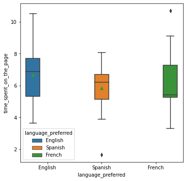

```python
#lets draw the box plot for visualization
fig, ax = plt.subplots(figsize = (6,6))
a = sns.boxplot(x= 'language_preferred', y = 'time_spent_on_the_page' , showmeans = True,data = timespentonnewpage, hue = 'language_preferred')
plt.show()
```

Now, the normality and equality of variance assumptions need to be checked.

```
For testing of normality, Shapiro-Wilk’s test is applied to the response variable.

For equality of variance, Levene test is applied to the response variable.
```

Shapiro-Wilk’s test

We will test the null hypothesis

```
𝐻0:

Time Spent on the new page follows a normal distribution
```

against the alternative hypothesis

```
𝐻𝑎:
```

Time spent on the new page does not follow a normal distribution

```python
# Assumption 1: Normality
# import the required function
from scipy import stats

# find the p-value
w, p_value = stats.shapiro(timespentonnewpage['time_spent_on_the_page'])
print('The p-value is', p_value)
```

```
The p-value is 0.8040016293525696
```

```python
# print the conclusion based on p-value
if p_value < 0.05:
    print(f'As the p-value {p_value} is less than the level of significance, we reject the null hypothesis.')
else:
    print(f'As the p-value {p_value} is greater than the level of significance, we fail to reject the null hypothesis.')
```

```
As the p-value 0.8040016293525696 is greater than the level of significance, we fail to reject the null hypothesis.
```

```python
As the pvalue from the test is very large, we fail to reject the null hypothesis.
Time spent on the new page follows a normal distribution.
```

Levene’s test

We will test the null hypothesis

```
𝐻0

: All the population variances are equal
```

against the alternative hypothesis

```
𝐻𝑎
```

: At least one variance is different from the rest

```python
#Assumption 2: Homogeneity of Variance
#import the required function
from scipy.stats import levene
statistic, p_value = levene( timespentonnewpage['time_spent_on_the_page'][timespentonnewpage['language_preferred']=="English"],
                                   timespentonnewpage['time_spent_on_the_page'][timespentonnewpage['language_preferred']=="Spanish"],
                                   timespentonnewpage['time_spent_on_the_page'][timespentonnewpage['language_preferred']=="French"])
# find the p-value
print('The p-value is', p_value)
```

```
The p-value is 0.46711357711340173
```

```python
# print the conclusion based on p-value
if p_value < 0.05:
    print(f'As the p-value {p_value} is less than the level of significance, we reject the null hypothesis.')
else:
    print(f'As the p-value {p_value} is greater than the level of significance, we fail to reject the null hypothesis.')
```

```
As the p-value 0.46711357711340173 is greater than the level of significance, we fail to reject the null hypothesis.
```

As p-value is greater , we fail to reject the null hypothesis.

We can conclude that All the population variances are equal.

Let's test whether the assumptions are satisfied or not

```
The populations are normally distributed - Yes, the normality assumption is verified using the Shapiro-Wilk’s test.
Samples are independent simple random samples - Yes, we are informed that the collected sample is a simple random sample.
Population variances are equal - Yes, the homogeneity of variance assumption is verified using the Levene's test.
```

## Let's find the p-value

```python
#import the required function
from scipy.stats import f_oneway

# perform one-way anova test
test_stat, p_value = f_oneway(timespentonnewpage.loc[timespentonnewpage['language_preferred'] == 'English', 'time_spent_on_the_page'],
                              timespentonnewpage.loc[timespentonnewpage['language_preferred'] == 'Spanish', 'time_spent_on_the_page'],
                              timespentonnewpage.loc[timespentonnewpage['language_preferred'] == 'French', 'time_spent_on_the_page'])
print('The p-value is ' + str(p_value))
```

```
The p-value is 0.43204138694325955
```

```python
# print the conclusion based on p-value
if p_value < 0.05:
    print(f'As the p-value {p_value} is less than the level of significance, we reject the null hypothesis.')
else:
    print(f'As the p-value {p_value} is greater than the level of significance, we fail to reject the null hypothesis.')
```

```
As the p-value 0.43204138694325955 is greater than the level of significance, we fail to reject the null hypothesis.
```

As p value is greater we fail to reject the null hypothesis. We can conclude that time spent on new landing page is same for all preferred languages like English, Spanish and French.

#### we can do a multiple comparision test(Tukey HSD) if we would have rejected the null hypothesis.

# Multiple Comparison test (Tukey HSD)

```python
#import the required function
from statsmodels.stats.multicomp import pairwise_tukeyhsd

# perform multiple pairwise comparison (Tukey HSD)
m_comp = pairwise_tukeyhsd(endog = timespentonnewpage['time_spent_on_the_page'], groups = timespentonnewpage['language_preferred'], alpha = 0.05)
print(m_comp)
```

```
 Multiple Comparison of Means - Tukey HSD, FWER=0.05
=====================================================
 group1  group2 meandiff p-adj   lower  upper  reject
-----------------------------------------------------
English  French  -0.4673 0.7259 -2.0035  1.069  False
English Spanish  -0.8285  0.401 -2.3647 0.7078  False
 French Spanish  -0.3612  0.816  -1.874 1.1516  False
-----------------------------------------------------
```

Tukey HSD also confirms us that the means of timespent on the new landing page is same for preferred languages like English, Spanish and French.